# Data Wrangling

The main purpose of this project is to use real world data to wrangle (gather, assess, clean) and then apply analysis with visualizations. The data used was from the Twitter account ‘WeRateDogs’ (@dog_rates) which “rates people's dogs with a humorous comments about the dog. These ratings almost always have a denominator of 10. The numerators, though? Almost always greater than 10. 11/10, 12/10, 13/10, etc.” (Project Overview, Udacity). There are three pieces of data that will be gathered, cleaned, and then merged together to make one final DataFrame to analyze.

> By Ahmed Glal

## Gathering the Data

First table archive downloaded from the internet manually and programmatically opened into a pandas DataFrame.

```python
!pip install tweepy
```

```
     |████████████████████████████████| 153kB 11.9MB/s
```

```python
# Downloading and importing all the necessary libraries to complete the project.
import pandas as pd
import requests
import tweepy
import os
import json
import numpy as np
import re
%matplotlib inline
```

```python
for dirname, _, filenames in os.walk('/kaggle/input'):
    for filename in filenames:
        print(os.path.join(dirname, filename))
```

```
/kaggle/input/tweet_json.txt
/kaggle/input/twitter-archive-enhanced.csv
```

```python
url = 'https://d17h27t6h515a5.cloudfront.net/topher/2017/August/599fd2ad_image-predictions/image-predictions.tsv'
response = requests.get(url)
with open(os.path.join(os.getcwd(), url.split('/')[-1]), mode='wb') as file:
    file.write(response.content)
```

Since, the input directory is a read-only directory. So,we can write the file into the working directory.

```python
for dirname, _, filenames in os.walk('/kaggle/working'):
    for filename in filenames:
        print(os.path.join(dirname, filename))
```

```
/kaggle/working/image-predictions.tsv
/kaggle/working/__notebook__.ipynb
/kaggle/working/__output__.json
```

Get your credentials from [here](https://developer.twitter.com/en.html)

```python
consumer_key = 'U4hUt6MkwsBunrLeP7gBrfs9q'
consumer_secret = '9RBX4KeUOxVhBRab0TBHjDcJp9hcSyvHieyA50as2auN5PxzWJ'
access_token = '1929558530-UuS1sgoWlZtz5xHhJVbWpq0pWoCdR9X7H8Cq89P'
access_secret = '36sqFNfP4b8QIY374adQUgUBrk0Ui5UEB4i3Z5e2qS5Qm'
```

```python
auth = tweepy.OAuthHandler(consumer_key, consumer_secret)
auth.set_access_token(access_token, access_secret)

api = tweepy.API(auth, parser=tweepy.parsers.JSONParser(), wait_on_rate_limit=True)
```

```python
#Code template above provided by Udacity.

df_twitter_archive = pd.read_csv('../input/twitter-archive-enhanced.csv')
```

```python
for tweet_id in df_twitter_archive.tweet_id:
    try:
        tweet_json = api.get_status(tweet_id, tweet_mode = 'extented')
        with open('/kaggle/working/tweet_json.txt', mode='a') as file:
            json.dump(tweet_json, file)
            file.write('\n')
    except Exception as e:
        print(str(tweet_id) + ': ' + str(e))
```

```
888202515573088257: [{'code': 144, 'message': 'No status found with that ID.'}]
873697596434513921: [{'code': 144, 'message': 'No status found with that ID.'}]
872668790621863937: [{'code': 144, 'message': 'No status found with that ID.'}]
872261713294495745: [{'code': 144, 'message': 'No status found with that ID.'}]
869988702071779329: [{'code': 144, 'message': 'No status found with that ID.'}]
866816280283807744: [{'code': 144, 'message': 'No status found with that ID.'}]
861769973181624320: [{'code': 144, 'message': 'No status found with that ID.'}]
856602993587888130: [{'code': 144, 'message': 'No status found with that ID.'}]
851953902622658560: [{'code': 144, 'message': 'No status found with that ID.'}]
845459076796616705: [{'code': 144, 'message': 'No status found with that ID.'}]
844704788403113984: [{'code': 144, 'message': 'No status found with that ID.'}]
842892208864923648: [{'code': 144, 'message': 'No status found with that ID.'}]
837366284874571778: [{'code': 144, 'message': 'No status found with that ID.'}]
837012587749474308: [{'code': 144, 'message': 'No status found with that ID.'}]
829374341691346946: [{'code': 144, 'message': 'No status found with that ID.'}]
827228250799742977: [{'code': 144, 'message': 'No status found with that ID.'}]
812747805718642688: [{'code': 144, 'message': 'No status found with that ID.'}]
802247111496568832: [{'code': 144, 'message': 'No status found with that ID.'}]
779123168116150273: [{'code': 144, 'message': 'No status found with that ID.'}]
775096608509886464: [{'code': 144, 'message': 'No status found with that ID.'}]
770743923962707968: [{'code': 144, 'message': 'No status found with that ID.'}]
754011816964026368: [{'code': 144, 'message': 'No status found with that ID.'}]
680055455951884288: [{'code': 144, 'message': 'No status found with that ID.'}]
```

```python
lists = [] #an empyty list to store a dictionaries
with open('/kaggle/working/tweet_json.txt') as file:
    lines = file.read().splitlines()
    for line in lines:
        data = json.loads(line)
        row = {
            'tweet_id'      : data['id'],
            'retweet_count' : data['retweet_count'],
            'favorite_count': data['favorite_count']
        }
        lists.append(row)
df_tweet_data = pd.DataFrame(lists,columns=['tweet_id','retweet_count','favorite_count'])
```

```python
# Downloading the image predictions from the internet

df_img_predictions = pd.read_csv('/kaggle/working/image-predictions.tsv', sep='\t')
```

## Assess

Visual

```python
df_twitter_archive
```

|  | tweet_id | in_reply_to_status_id | in_reply_to_user_id | timestamp | source | text | retweeted_status_id | retweeted_status_user_id | retweeted_status_timestamp | expanded_urls | rating_numerator | rating_denominator | name | doggo | floofer | pupper | puppo |
| --- | --- | --- | --- | --- | --- | --- | --- | --- | --- | --- | --- | --- | --- | --- | --- | --- | --- |
| 0 | 892420643555336193 | NaN | NaN | 2017-08-01 16:23:56 +0000 | <a href="http://twitter.com/download/iphone" r... | This is Phineas. He's a mystical boy. Only eve... | NaN | NaN | NaN | https://twitter.com/dog_rates/status/892420643... | 13 | 10 | Phineas | None | None | None | None |
| 1 | 892177421306343426 | NaN | NaN | 2017-08-01 00:17:27 +0000 | <a href="http://twitter.com/download/iphone" r... | This is Tilly. She's just checking pup on you.... | NaN | NaN | NaN | https://twitter.com/dog_rates/status/892177421... | 13 | 10 | Tilly | None | None | None | None |
| 2 | 891815181378084864 | NaN | NaN | 2017-07-31 00:18:03 +0000 | <a href="http://twitter.com/download/iphone" r... | This is Archie. He is a rare Norwegian Pouncin... | NaN | NaN | NaN | https://twitter.com/dog_rates/status/891815181... | 12 | 10 | Archie | None | None | None | None |
| 3 | 891689557279858688 | NaN | NaN | 2017-07-30 15:58:51 +0000 | <a href="http://twitter.com/download/iphone" r... | This is Darla. She commenced a snooze mid meal... | NaN | NaN | NaN | https://twitter.com/dog_rates/status/891689557... | 13 | 10 | Darla | None | None | None | None |
| 4 | 891327558926688256 | NaN | NaN | 2017-07-29 16:00:24 +0000 | <a href="http://twitter.com/download/iphone" r... | This is Franklin. He would like you to stop ca... | NaN | NaN | NaN | https://twitter.com/dog_rates/status/891327558... | 12 | 10 | Franklin | None | None | None | None |
| 5 | 891087950875897856 | NaN | NaN | 2017-07-29 00:08:17 +0000 | <a href="http://twitter.com/download/iphone" r... | Here we have a majestic great white breaching ... | NaN | NaN | NaN | https://twitter.com/dog_rates/status/891087950... | 13 | 10 | None | None | None | None | None |
| 6 | 890971913173991426 | NaN | NaN | 2017-07-28 16:27:12 +0000 | <a href="http://twitter.com/download/iphone" r... | Meet Jax. He enjoys ice cream so much he gets ... | NaN | NaN | NaN | https://gofundme.com/ydvmve-surgery-for-jax,ht... | 13 | 10 | Jax | None | None | None | None |
| 7 | 890729181411237888 | NaN | NaN | 2017-07-28 00:22:40 +0000 | <a href="http://twitter.com/download/iphone" r... | When you watch your owner call another dog a g... | NaN | NaN | NaN | https://twitter.com/dog_rates/status/890729181... | 13 | 10 | None | None | None | None | None |
| 8 | 890609185150312448 | NaN | NaN | 2017-07-27 16:25:51 +0000 | <a href="http://twitter.com/download/iphone" r... | This is Zoey. She doesn't want to be one of th... | NaN | NaN | NaN | https://twitter.com/dog_rates/status/890609185... | 13 | 10 | Zoey | None | None | None | None |
| 9 | 890240255349198849 | NaN | NaN | 2017-07-26 15:59:51 +0000 | <a href="http://twitter.com/download/iphone" r... | This is Cassie. She is a college pup. Studying... | NaN | NaN | NaN | https://twitter.com/dog_rates/status/890240255... | 14 | 10 | Cassie | doggo | None | None | None |
| 10 | 890006608113172480 | NaN | NaN | 2017-07-26 00:31:25 +0000 | <a href="http://twitter.com/download/iphone" r... | This is Koda. He is a South Australian decksha... | NaN | NaN | NaN | https://twitter.com/dog_rates/status/890006608... | 13 | 10 | Koda | None | None | None | None |
| 11 | 889880896479866881 | NaN | NaN | 2017-07-25 16:11:53 +0000 | <a href="http://twitter.com/download/iphone" r... | This is Bruno. He is a service shark. Only get... | NaN | NaN | NaN | https://twitter.com/dog_rates/status/889880896... | 13 | 10 | Bruno | None | None | None | None |
| 12 | 889665388333682689 | NaN | NaN | 2017-07-25 01:55:32 +0000 | <a href="http://twitter.com/download/iphone" r... | Here's a puppo that seems to be on the fence a... | NaN | NaN | NaN | https://twitter.com/dog_rates/status/889665388... | 13 | 10 | None | None | None | None | puppo |
| 13 | 889638837579907072 | NaN | NaN | 2017-07-25 00:10:02 +0000 | <a href="http://twitter.com/download/iphone" r... | This is Ted. He does his best. Sometimes that'... | NaN | NaN | NaN | https://twitter.com/dog_rates/status/889638837... | 12 | 10 | Ted | None | None | None | None |
| 14 | 889531135344209921 | NaN | NaN | 2017-07-24 17:02:04 +0000 | <a href="http://twitter.com/download/iphone" r... | This is Stuart. He's sporting his favorite fan... | NaN | NaN | NaN | https://twitter.com/dog_rates/status/889531135... | 13 | 10 | Stuart | None | None | None | puppo |
| 15 | 889278841981685760 | NaN | NaN | 2017-07-24 00:19:32 +0000 | <a href="http://twitter.com/download/iphone" r... | This is Oliver. You're witnessing one of his m... | NaN | NaN | NaN | https://twitter.com/dog_rates/status/889278841... | 13 | 10 | Oliver | None | None | None | None |
| 16 | 888917238123831296 | NaN | NaN | 2017-07-23 00:22:39 +0000 | <a href="http://twitter.com/download/iphone" r... | This is Jim. He found a fren. Taught him how t... | NaN | NaN | NaN | https://twitter.com/dog_rates/status/888917238... | 12 | 10 | Jim | None | None | None | None |
| 17 | 888804989199671297 | NaN | NaN | 2017-07-22 16:56:37 +0000 | <a href="http://twitter.com/download/iphone" r... | This is Zeke. He has a new stick. Very proud o... | NaN | NaN | NaN | https://twitter.com/dog_rates/status/888804989... | 13 | 10 | Zeke | None | None | None | None |
| 18 | 888554962724278272 | NaN | NaN | 2017-07-22 00:23:06 +0000 | <a href="http://twitter.com/download/iphone" r... | This is Ralphus. He's powering up. Attempting ... | NaN | NaN | NaN | https://twitter.com/dog_rates/status/888554962... | 13 | 10 | Ralphus | None | None | None | None |
| 19 | 888202515573088257 | NaN | NaN | 2017-07-21 01:02:36 +0000 | <a href="http://twitter.com/download/iphone" r... | RT @dog_rates: This is Canela. She attempted s... | 8.874740e+17 | 4.196984e+09 | 2017-07-19 00:47:34 +0000 | https://twitter.com/dog_rates/status/887473957... | 13 | 10 | Canela | None | None | None | None |
| 20 | 888078434458587136 | NaN | NaN | 2017-07-20 16:49:33 +0000 | <a href="http://twitter.com/download/iphone" r... | This is Gerald. He was just told he didn't get... | NaN | NaN | NaN | https://twitter.com/dog_rates/status/888078434... | 12 | 10 | Gerald | None | None | None | None |
| 21 | 887705289381826560 | NaN | NaN | 2017-07-19 16:06:48 +0000 | <a href="http://twitter.com/download/iphone" r... | This is Jeffrey. He has a monopoly on the pool... | NaN | NaN | NaN | https://twitter.com/dog_rates/status/887705289... | 13 | 10 | Jeffrey | None | None | None | None |
| 22 | 887517139158093824 | NaN | NaN | 2017-07-19 03:39:09 +0000 | <a href="http://twitter.com/download/iphone" r... | I've yet to rate a Venezuelan Hover Wiener. Th... | NaN | NaN | NaN | https://twitter.com/dog_rates/status/887517139... | 14 | 10 | such | None | None | None | None |
| 23 | 887473957103951883 | NaN | NaN | 2017-07-19 00:47:34 +0000 | <a href="http://twitter.com/download/iphone" r... | This is Canela. She attempted some fancy porch... | NaN | NaN | NaN | https://twitter.com/dog_rates/status/887473957... | 13 | 10 | Canela | None | None | None | None |
| 24 | 887343217045368832 | NaN | NaN | 2017-07-18 16:08:03 +0000 | <a href="http://twitter.com/download/iphone" r... | You may not have known you needed to see this ... | NaN | NaN | NaN | https://twitter.com/dog_rates/status/887343217... | 13 | 10 | None | None | None | None | None |
| 25 | 887101392804085760 | NaN | NaN | 2017-07-18 00:07:08 +0000 | <a href="http://twitter.com/download/iphone" r... | This... is a Jubilant Antarctic House Bear. We... | NaN | NaN | NaN | https://twitter.com/dog_rates/status/887101392... | 12 | 10 | None | None | None | None | None |
| 26 | 886983233522544640 | NaN | NaN | 2017-07-17 16:17:36 +0000 | <a href="http://twitter.com/download/iphone" r... | This is Maya. She's very shy. Rarely leaves he... | NaN | NaN | NaN | https://twitter.com/dog_rates/status/886983233... | 13 | 10 | Maya | None | None | None | None |
| 27 | 886736880519319552 | NaN | NaN | 2017-07-16 23:58:41 +0000 | <a href="http://twitter.com/download/iphone" r... | This is Mingus. He's a wonderful father to his... | NaN | NaN | NaN | https://www.gofundme.com/mingusneedsus,https:/... | 13 | 10 | Mingus | None | None | None | None |
| 28 | 886680336477933568 | NaN | NaN | 2017-07-16 20:14:00 +0000 | <a href="http://twitter.com/download/iphone" r... | This is Derek. He's late for a dog meeting. 13... | NaN | NaN | NaN | https://twitter.com/dog_rates/status/886680336... | 13 | 10 | Derek | None | None | None | None |
| 29 | 886366144734445568 | NaN | NaN | 2017-07-15 23:25:31 +0000 | <a href="http://twitter.com/download/iphone" r... | This is Roscoe. Another pupper fallen victim t... | NaN | NaN | NaN | https://twitter.com/dog_rates/status/886366144... | 12 | 10 | Roscoe | None | None | pupper | None |
| ... | ... | ... | ... | ... | ... | ... | ... | ... | ... | ... | ... | ... | ... | ... | ... | ... | ... |
| 2326 | 666411507551481857 | NaN | NaN | 2015-11-17 00:24:19 +0000 | <a href="http://twitter.com/download/iphone" r... | This is quite the dog. Gets really excited whe... | NaN | NaN | NaN | https://twitter.com/dog_rates/status/666411507... | 2 | 10 | quite | None | None | None | None |
| 2327 | 666407126856765440 | NaN | NaN | 2015-11-17 00:06:54 +0000 | <a href="http://twitter.com/download/iphone" r... | This is a southern Vesuvius bumblegruff. Can d... | NaN | NaN | NaN | https://twitter.com/dog_rates/status/666407126... | 7 | 10 | a | None | None | None | None |
| 2328 | 666396247373291520 | NaN | NaN | 2015-11-16 23:23:41 +0000 | <a href="http://twitter.com/download/iphone" r... | Oh goodness. A super rare northeast Qdoba kang... | NaN | NaN | NaN | https://twitter.com/dog_rates/status/666396247... | 9 | 10 | None | None | None | None | None |
| 2329 | 666373753744588802 | NaN | NaN | 2015-11-16 21:54:18 +0000 | <a href="http://twitter.com/download/iphone" r... | Those are sunglasses and a jean jacket. 11/10 ... | NaN | NaN | NaN | https://twitter.com/dog_rates/status/666373753... | 11 | 10 | None | None | None | None | None |
| 2330 | 666362758909284353 | NaN | NaN | 2015-11-16 21:10:36 +0000 | <a href="http://twitter.com/download/iphone" r... | Unique dog here. Very small. Lives in containe... | NaN | NaN | NaN | https://twitter.com/dog_rates/status/666362758... | 6 | 10 | None | None | None | None | None |
| 2331 | 666353288456101888 | NaN | NaN | 2015-11-16 20:32:58 +0000 | <a href="http://twitter.com/download/iphone" r... | Here we have a mixed Asiago from the Galápagos... | NaN | NaN | NaN | https://twitter.com/dog_rates/status/666353288... | 8 | 10 | None | None | None | None | None |
| 2332 | 666345417576210432 | NaN | NaN | 2015-11-16 20:01:42 +0000 | <a href="http://twitter.com/download/iphone" r... | Look at this jokester thinking seat belt laws ... | NaN | NaN | NaN | https://twitter.com/dog_rates/status/666345417... | 10 | 10 | None | None | None | None | None |
| 2333 | 666337882303524864 | NaN | NaN | 2015-11-16 19:31:45 +0000 | <a href="http://twitter.com/download/iphone" r... | This is an extremely rare horned Parthenon. No... | NaN | NaN | NaN | https://twitter.com/dog_rates/status/666337882... | 9 | 10 | an | None | None | None | None |
| 2334 | 666293911632134144 | NaN | NaN | 2015-11-16 16:37:02 +0000 | <a href="http://twitter.com/download/iphone" r... | This is a funny dog. Weird toes. Won't come do... | NaN | NaN | NaN | https://twitter.com/dog_rates/status/666293911... | 3 | 10 | a | None | None | None | None |
| 2335 | 666287406224695296 | NaN | NaN | 2015-11-16 16:11:11 +0000 | <a href="http://twitter.com/download/iphone" r... | This is an Albanian 3 1/2 legged Episcopalian... | NaN | NaN | NaN | https://twitter.com/dog_rates/status/666287406... | 1 | 2 | an | None | None | None | None |
| 2336 | 666273097616637952 | NaN | NaN | 2015-11-16 15:14:19 +0000 | <a href="http://twitter.com/download/iphone" r... | Can take selfies 11/10 https://t.co/ws2AMaNwPW | NaN | NaN | NaN | https://twitter.com/dog_rates/status/666273097... | 11 | 10 | None | None | None | None | None |
| 2337 | 666268910803644416 | NaN | NaN | 2015-11-16 14:57:41 +0000 | <a href="http://twitter.com/download/iphone" r... | Very concerned about fellow dog trapped in com... | NaN | NaN | NaN | https://twitter.com/dog_rates/status/666268910... | 10 | 10 | None | None | None | None | None |
| 2338 | 666104133288665088 | NaN | NaN | 2015-11-16 04:02:55 +0000 | <a href="http://twitter.com/download/iphone" r... | Not familiar with this breed. No tail (weird).... | NaN | NaN | NaN | https://twitter.com/dog_rates/status/666104133... | 1 | 10 | None | None | None | None | None |
| 2339 | 666102155909144576 | NaN | NaN | 2015-11-16 03:55:04 +0000 | <a href="http://twitter.com/download/iphone" r... | Oh my. Here you are seeing an Adobe Setter giv... | NaN | NaN | NaN | https://twitter.com/dog_rates/status/666102155... | 11 | 10 | None | None | None | None | None |
| 2340 | 666099513787052032 | NaN | NaN | 2015-11-16 03:44:34 +0000 | <a href="http://twitter.com/download/iphone" r... | Can stand on stump for what seems like a while... | NaN | NaN | NaN | https://twitter.com/dog_rates/status/666099513... | 8 | 10 | None | None | None | None | None |
| 2341 | 666094000022159362 | NaN | NaN | 2015-11-16 03:22:39 +0000 | <a href="http://twitter.com/download/iphone" r... | This appears to be a Mongolian Presbyterian mi... | NaN | NaN | NaN | https://twitter.com/dog_rates/status/666094000... | 9 | 10 | None | None | None | None | None |
| 2342 | 666082916733198337 | NaN | NaN | 2015-11-16 02:38:37 +0000 | <a href="http://twitter.com/download/iphone" r... | Here we have a well-established sunblockerspan... | NaN | NaN | NaN | https://twitter.com/dog_rates/status/666082916... | 6 | 10 | None | None | None | None | None |
| 2343 | 666073100786774016 | NaN | NaN | 2015-11-16 01:59:36 +0000 | <a href="http://twitter.com/download/iphone" r... | Let's hope this flight isn't Malaysian (lol). ... | NaN | NaN | NaN | https://twitter.com/dog_rates/status/666073100... | 10 | 10 | None | None | None | None | None |
| 2344 | 666071193221509120 | NaN | NaN | 2015-11-16 01:52:02 +0000 | <a href="http://twitter.com/download/iphone" r... | Here we have a northern speckled Rhododendron.... | NaN | NaN | NaN | https://twitter.com/dog_rates/status/666071193... | 9 | 10 | None | None | None | None | None |
| 2345 | 666063827256086533 | NaN | NaN | 2015-11-16 01:22:45 +0000 | <a href="http://twitter.com/download/iphone" r... | This is the happiest dog you will ever see. Ve... | NaN | NaN | NaN | https://twitter.com/dog_rates/status/666063827... | 10 | 10 | the | None | None | None | None |
| 2346 | 666058600524156928 | NaN | NaN | 2015-11-16 01:01:59 +0000 | <a href="http://twitter.com/download/iphone" r... | Here is the Rand Paul of retrievers folks! He'... | NaN | NaN | NaN | https://twitter.com/dog_rates/status/666058600... | 8 | 10 | the | None | None | None | None |
| 2347 | 666057090499244032 | NaN | NaN | 2015-11-16 00:55:59 +0000 | <a href="http://twitter.com/download/iphone" r... | My oh my. This is a rare blond Canadian terrie... | NaN | NaN | NaN | https://twitter.com/dog_rates/status/666057090... | 9 | 10 | a | None | None | None | None |
| 2348 | 666055525042405380 | NaN | NaN | 2015-11-16 00:49:46 +0000 | <a href="http://twitter.com/download/iphone" r... | Here is a Siberian heavily armored polar bear ... | NaN | NaN | NaN | https://twitter.com/dog_rates/status/666055525... | 10 | 10 | a | None | None | None | None |
| 2349 | 666051853826850816 | NaN | NaN | 2015-11-16 00:35:11 +0000 | <a href="http://twitter.com/download/iphone" r... | This is an odd dog. Hard on the outside but lo... | NaN | NaN | NaN | https://twitter.com/dog_rates/status/666051853... | 2 | 10 | an | None | None | None | None |
| 2350 | 666050758794694657 | NaN | NaN | 2015-11-16 00:30:50 +0000 | <a href="http://twitter.com/download/iphone" r... | This is a truly beautiful English Wilson Staff... | NaN | NaN | NaN | https://twitter.com/dog_rates/status/666050758... | 10 | 10 | a | None | None | None | None |
| 2351 | 666049248165822465 | NaN | NaN | 2015-11-16 00:24:50 +0000 | <a href="http://twitter.com/download/iphone" r... | Here we have a 1949 1st generation vulpix. Enj... | NaN | NaN | NaN | https://twitter.com/dog_rates/status/666049248... | 5 | 10 | None | None | None | None | None |
| 2352 | 666044226329800704 | NaN | NaN | 2015-11-16 00:04:52 +0000 | <a href="http://twitter.com/download/iphone" r... | This is a purebred Piers Morgan. Loves to Netf... | NaN | NaN | NaN | https://twitter.com/dog_rates/status/666044226... | 6 | 10 | a | None | None | None | None |
| 2353 | 666033412701032449 | NaN | NaN | 2015-11-15 23:21:54 +0000 | <a href="http://twitter.com/download/iphone" r... | Here is a very happy pup. Big fan of well-main... | NaN | NaN | NaN | https://twitter.com/dog_rates/status/666033412... | 9 | 10 | a | None | None | None | None |
| 2354 | 666029285002620928 | NaN | NaN | 2015-11-15 23:05:30 +0000 | <a href="http://twitter.com/download/iphone" r... | This is a western brown Mitsubishi terrier. Up... | NaN | NaN | NaN | https://twitter.com/dog_rates/status/666029285... | 7 | 10 | a | None | None | None | None |
| 2355 | 666020888022790149 | NaN | NaN | 2015-11-15 22:32:08 +0000 | <a href="http://twitter.com/download/iphone" r... | Here we have a Japanese Irish Setter. Lost eye... | NaN | NaN | NaN | https://twitter.com/dog_rates/status/666020888... | 8 | 10 | None | None | None | None | None |

2356 rows × 17 columns

```python
df_img_predictions
```

|  | tweet_id | jpg_url | img_num | p1 | p1_conf | p1_dog | p2 | p2_conf | p2_dog | p3 | p3_conf | p3_dog |
| --- | --- | --- | --- | --- | --- | --- | --- | --- | --- | --- | --- | --- |
| 0 | 666020888022790149 | https://pbs.twimg.com/media/CT4udn0WwAA0aMy.jpg | 1 | Welsh_springer_spaniel | 0.465074 | True | collie | 0.156665 | True | Shetland_sheepdog | 0.061428 | True |
| 1 | 666029285002620928 | https://pbs.twimg.com/media/CT42GRgUYAA5iDo.jpg | 1 | redbone | 0.506826 | True | miniature_pinscher | 0.074192 | True | Rhodesian_ridgeback | 0.072010 | True |
| 2 | 666033412701032449 | https://pbs.twimg.com/media/CT4521TWwAEvMyu.jpg | 1 | German_shepherd | 0.596461 | True | malinois | 0.138584 | True | bloodhound | 0.116197 | True |
| 3 | 666044226329800704 | https://pbs.twimg.com/media/CT5Dr8HUEAA-lEu.jpg | 1 | Rhodesian_ridgeback | 0.408143 | True | redbone | 0.360687 | True | miniature_pinscher | 0.222752 | True |
| 4 | 666049248165822465 | https://pbs.twimg.com/media/CT5IQmsXIAAKY4A.jpg | 1 | miniature_pinscher | 0.560311 | True | Rottweiler | 0.243682 | True | Doberman | 0.154629 | True |
| 5 | 666050758794694657 | https://pbs.twimg.com/media/CT5Jof1WUAEuVxN.jpg | 1 | Bernese_mountain_dog | 0.651137 | True | English_springer | 0.263788 | True | Greater_Swiss_Mountain_dog | 0.016199 | True |
| 6 | 666051853826850816 | https://pbs.twimg.com/media/CT5KoJ1WoAAJash.jpg | 1 | box_turtle | 0.933012 | False | mud_turtle | 0.045885 | False | terrapin | 0.017885 | False |
| 7 | 666055525042405380 | https://pbs.twimg.com/media/CT5N9tpXIAAifs1.jpg | 1 | chow | 0.692517 | True | Tibetan_mastiff | 0.058279 | True | fur_coat | 0.054449 | False |
| 8 | 666057090499244032 | https://pbs.twimg.com/media/CT5PY90WoAAQGLo.jpg | 1 | shopping_cart | 0.962465 | False | shopping_basket | 0.014594 | False | golden_retriever | 0.007959 | True |
| 9 | 666058600524156928 | https://pbs.twimg.com/media/CT5Qw94XAAA_2dP.jpg | 1 | miniature_poodle | 0.201493 | True | komondor | 0.192305 | True | soft-coated_wheaten_terrier | 0.082086 | True |
| 10 | 666063827256086533 | https://pbs.twimg.com/media/CT5Vg_wXIAAXfnj.jpg | 1 | golden_retriever | 0.775930 | True | Tibetan_mastiff | 0.093718 | True | Labrador_retriever | 0.072427 | True |
| 11 | 666071193221509120 | https://pbs.twimg.com/media/CT5cN_3WEAAlOoZ.jpg | 1 | Gordon_setter | 0.503672 | True | Yorkshire_terrier | 0.174201 | True | Pekinese | 0.109454 | True |
| 12 | 666073100786774016 | https://pbs.twimg.com/media/CT5d9DZXAAALcwe.jpg | 1 | Walker_hound | 0.260857 | True | English_foxhound | 0.175382 | True | Ibizan_hound | 0.097471 | True |
| 13 | 666082916733198337 | https://pbs.twimg.com/media/CT5m4VGWEAAtKc8.jpg | 1 | pug | 0.489814 | True | bull_mastiff | 0.404722 | True | French_bulldog | 0.048960 | True |
| 14 | 666094000022159362 | https://pbs.twimg.com/media/CT5w9gUW4AAsBNN.jpg | 1 | bloodhound | 0.195217 | True | German_shepherd | 0.078260 | True | malinois | 0.075628 | True |
| 15 | 666099513787052032 | https://pbs.twimg.com/media/CT51-JJUEAA6hV8.jpg | 1 | Lhasa | 0.582330 | True | Shih-Tzu | 0.166192 | True | Dandie_Dinmont | 0.089688 | True |
| 16 | 666102155909144576 | https://pbs.twimg.com/media/CT54YGiWUAEZnoK.jpg | 1 | English_setter | 0.298617 | True | Newfoundland | 0.149842 | True | borzoi | 0.133649 | True |
| 17 | 666104133288665088 | https://pbs.twimg.com/media/CT56LSZWoAAlJj2.jpg | 1 | hen | 0.965932 | False | cock | 0.033919 | False | partridge | 0.000052 | False |
| 18 | 666268910803644416 | https://pbs.twimg.com/media/CT8QCd1WEAADXws.jpg | 1 | desktop_computer | 0.086502 | False | desk | 0.085547 | False | bookcase | 0.079480 | False |
| 19 | 666273097616637952 | https://pbs.twimg.com/media/CT8T1mtUwAA3aqm.jpg | 1 | Italian_greyhound | 0.176053 | True | toy_terrier | 0.111884 | True | basenji | 0.111152 | True |
| 20 | 666287406224695296 | https://pbs.twimg.com/media/CT8g3BpUEAAuFjg.jpg | 1 | Maltese_dog | 0.857531 | True | toy_poodle | 0.063064 | True | miniature_poodle | 0.025581 | True |
| 21 | 666293911632134144 | https://pbs.twimg.com/media/CT8mx7KW4AEQu8N.jpg | 1 | three-toed_sloth | 0.914671 | False | otter | 0.015250 | False | great_grey_owl | 0.013207 | False |
| 22 | 666337882303524864 | https://pbs.twimg.com/media/CT9OwFIWEAMuRje.jpg | 1 | ox | 0.416669 | False | Newfoundland | 0.278407 | True | groenendael | 0.102643 | True |
| 23 | 666345417576210432 | https://pbs.twimg.com/media/CT9Vn7PWoAA_ZCM.jpg | 1 | golden_retriever | 0.858744 | True | Chesapeake_Bay_retriever | 0.054787 | True | Labrador_retriever | 0.014241 | True |
| 24 | 666353288456101888 | https://pbs.twimg.com/media/CT9cx0tUEAAhNN_.jpg | 1 | malamute | 0.336874 | True | Siberian_husky | 0.147655 | True | Eskimo_dog | 0.093412 | True |
| 25 | 666362758909284353 | https://pbs.twimg.com/media/CT9lXGsUcAAyUFt.jpg | 1 | guinea_pig | 0.996496 | False | skunk | 0.002402 | False | hamster | 0.000461 | False |
| 26 | 666373753744588802 | https://pbs.twimg.com/media/CT9vZEYWUAAlZ05.jpg | 1 | soft-coated_wheaten_terrier | 0.326467 | True | Afghan_hound | 0.259551 | True | briard | 0.206803 | True |
| 27 | 666396247373291520 | https://pbs.twimg.com/media/CT-D2ZHWIAA3gK1.jpg | 1 | Chihuahua | 0.978108 | True | toy_terrier | 0.009397 | True | papillon | 0.004577 | True |
| 28 | 666407126856765440 | https://pbs.twimg.com/media/CT-NvwmW4AAugGZ.jpg | 1 | black-and-tan_coonhound | 0.529139 | True | bloodhound | 0.244220 | True | flat-coated_retriever | 0.173810 | True |
| 29 | 666411507551481857 | https://pbs.twimg.com/media/CT-RugiWIAELEaq.jpg | 1 | coho | 0.404640 | False | barracouta | 0.271485 | False | gar | 0.189945 | False |
| ... | ... | ... | ... | ... | ... | ... | ... | ... | ... | ... | ... | ... |
| 2045 | 886366144734445568 | https://pbs.twimg.com/media/DE0BTnQUwAApKEH.jpg | 1 | French_bulldog | 0.999201 | True | Chihuahua | 0.000361 | True | Boston_bull | 0.000076 | True |
| 2046 | 886680336477933568 | https://pbs.twimg.com/media/DE4fEDzWAAAyHMM.jpg | 1 | convertible | 0.738995 | False | sports_car | 0.139952 | False | car_wheel | 0.044173 | False |
| 2047 | 886736880519319552 | https://pbs.twimg.com/media/DE5Se8FXcAAJFx4.jpg | 1 | kuvasz | 0.309706 | True | Great_Pyrenees | 0.186136 | True | Dandie_Dinmont | 0.086346 | True |
| 2048 | 886983233522544640 | https://pbs.twimg.com/media/DE8yicJW0AAAvBJ.jpg | 2 | Chihuahua | 0.793469 | True | toy_terrier | 0.143528 | True | can_opener | 0.032253 | False |
| 2049 | 887101392804085760 | https://pbs.twimg.com/media/DE-eAq6UwAA-jaE.jpg | 1 | Samoyed | 0.733942 | True | Eskimo_dog | 0.035029 | True | Staffordshire_bullterrier | 0.029705 | True |
| 2050 | 887343217045368832 | https://pbs.twimg.com/ext_tw_video_thumb/88734... | 1 | Mexican_hairless | 0.330741 | True | sea_lion | 0.275645 | False | Weimaraner | 0.134203 | True |
| 2051 | 887473957103951883 | https://pbs.twimg.com/media/DFDw2tyUQAAAFke.jpg | 2 | Pembroke | 0.809197 | True | Rhodesian_ridgeback | 0.054950 | True | beagle | 0.038915 | True |
| 2052 | 887517139158093824 | https://pbs.twimg.com/ext_tw_video_thumb/88751... | 1 | limousine | 0.130432 | False | tow_truck | 0.029175 | False | shopping_cart | 0.026321 | False |
| 2053 | 887705289381826560 | https://pbs.twimg.com/media/DFHDQBbXgAEqY7t.jpg | 1 | basset | 0.821664 | True | redbone | 0.087582 | True | Weimaraner | 0.026236 | True |
| 2054 | 888078434458587136 | https://pbs.twimg.com/media/DFMWn56WsAAkA7B.jpg | 1 | French_bulldog | 0.995026 | True | pug | 0.000932 | True | bull_mastiff | 0.000903 | True |
| 2055 | 888202515573088257 | https://pbs.twimg.com/media/DFDw2tyUQAAAFke.jpg | 2 | Pembroke | 0.809197 | True | Rhodesian_ridgeback | 0.054950 | True | beagle | 0.038915 | True |
| 2056 | 888554962724278272 | https://pbs.twimg.com/media/DFTH_O-UQAACu20.jpg | 3 | Siberian_husky | 0.700377 | True | Eskimo_dog | 0.166511 | True | malamute | 0.111411 | True |
| 2057 | 888804989199671297 | https://pbs.twimg.com/media/DFWra-3VYAA2piG.jpg | 1 | golden_retriever | 0.469760 | True | Labrador_retriever | 0.184172 | True | English_setter | 0.073482 | True |
| 2058 | 888917238123831296 | https://pbs.twimg.com/media/DFYRgsOUQAARGhO.jpg | 1 | golden_retriever | 0.714719 | True | Tibetan_mastiff | 0.120184 | True | Labrador_retriever | 0.105506 | True |
| 2059 | 889278841981685760 | https://pbs.twimg.com/ext_tw_video_thumb/88927... | 1 | whippet | 0.626152 | True | borzoi | 0.194742 | True | Saluki | 0.027351 | True |
| 2060 | 889531135344209921 | https://pbs.twimg.com/media/DFg_2PVW0AEHN3p.jpg | 1 | golden_retriever | 0.953442 | True | Labrador_retriever | 0.013834 | True | redbone | 0.007958 | True |
| 2061 | 889638837579907072 | https://pbs.twimg.com/media/DFihzFfXsAYGDPR.jpg | 1 | French_bulldog | 0.991650 | True | boxer | 0.002129 | True | Staffordshire_bullterrier | 0.001498 | True |
| 2062 | 889665388333682689 | https://pbs.twimg.com/media/DFi579UWsAAatzw.jpg | 1 | Pembroke | 0.966327 | True | Cardigan | 0.027356 | True | basenji | 0.004633 | True |
| 2063 | 889880896479866881 | https://pbs.twimg.com/media/DFl99B1WsAITKsg.jpg | 1 | French_bulldog | 0.377417 | True | Labrador_retriever | 0.151317 | True | muzzle | 0.082981 | False |
| 2064 | 890006608113172480 | https://pbs.twimg.com/media/DFnwSY4WAAAMliS.jpg | 1 | Samoyed | 0.957979 | True | Pomeranian | 0.013884 | True | chow | 0.008167 | True |
| 2065 | 890240255349198849 | https://pbs.twimg.com/media/DFrEyVuW0AAO3t9.jpg | 1 | Pembroke | 0.511319 | True | Cardigan | 0.451038 | True | Chihuahua | 0.029248 | True |
| 2066 | 890609185150312448 | https://pbs.twimg.com/media/DFwUU__XcAEpyXI.jpg | 1 | Irish_terrier | 0.487574 | True | Irish_setter | 0.193054 | True | Chesapeake_Bay_retriever | 0.118184 | True |
| 2067 | 890729181411237888 | https://pbs.twimg.com/media/DFyBahAVwAAhUTd.jpg | 2 | Pomeranian | 0.566142 | True | Eskimo_dog | 0.178406 | True | Pembroke | 0.076507 | True |
| 2068 | 890971913173991426 | https://pbs.twimg.com/media/DF1eOmZXUAALUcq.jpg | 1 | Appenzeller | 0.341703 | True | Border_collie | 0.199287 | True | ice_lolly | 0.193548 | False |
| 2069 | 891087950875897856 | https://pbs.twimg.com/media/DF3HwyEWsAABqE6.jpg | 1 | Chesapeake_Bay_retriever | 0.425595 | True | Irish_terrier | 0.116317 | True | Indian_elephant | 0.076902 | False |
| 2070 | 891327558926688256 | https://pbs.twimg.com/media/DF6hr6BUMAAzZgT.jpg | 2 | basset | 0.555712 | True | English_springer | 0.225770 | True | German_short-haired_pointer | 0.175219 | True |
| 2071 | 891689557279858688 | https://pbs.twimg.com/media/DF_q7IAWsAEuuN8.jpg | 1 | paper_towel | 0.170278 | False | Labrador_retriever | 0.168086 | True | spatula | 0.040836 | False |
| 2072 | 891815181378084864 | https://pbs.twimg.com/media/DGBdLU1WsAANxJ9.jpg | 1 | Chihuahua | 0.716012 | True | malamute | 0.078253 | True | kelpie | 0.031379 | True |
| 2073 | 892177421306343426 | https://pbs.twimg.com/media/DGGmoV4XsAAUL6n.jpg | 1 | Chihuahua | 0.323581 | True | Pekinese | 0.090647 | True | papillon | 0.068957 | True |
| 2074 | 892420643555336193 | https://pbs.twimg.com/media/DGKD1-bXoAAIAUK.jpg | 1 | orange | 0.097049 | False | bagel | 0.085851 | False | banana | 0.076110 | False |

2075 rows × 12 columns

```python
df_tweet_data
```

|  | tweet_id | retweet_count | favorite_count |
| --- | --- | --- | --- |
| 0 | 892420643555336193 | 7931 | 37120 |
| 1 | 892177421306343426 | 5893 | 31938 |
| 2 | 891815181378084864 | 3895 | 24048 |
| 3 | 891689557279858688 | 8085 | 40440 |
| 4 | 891327558926688256 | 8774 | 38666 |
| 5 | 891087950875897856 | 2913 | 19428 |
| 6 | 890971913173991426 | 1936 | 11337 |
| 7 | 890729181411237888 | 17696 | 62619 |
| 8 | 890609185150312448 | 4016 | 26735 |
| 9 | 890240255349198849 | 6900 | 30611 |
| 10 | 890006608113172480 | 6871 | 29469 |
| 11 | 889880896479866881 | 4680 | 26734 |
| 12 | 889665388333682689 | 9409 | 46135 |
| 13 | 889638837579907072 | 4223 | 26003 |
| 14 | 889531135344209921 | 2116 | 14519 |
| 15 | 889278841981685760 | 5023 | 24206 |
| 16 | 888917238123831296 | 4215 | 27952 |
| 17 | 888804989199671297 | 3993 | 24542 |
| 18 | 888554962724278272 | 3295 | 19006 |
| 19 | 888078434458587136 | 3262 | 20878 |
| 20 | 887705289381826560 | 5048 | 28992 |
| 21 | 887517139158093824 | 11004 | 44471 |
| 22 | 887473957103951883 | 16910 | 66125 |
| 23 | 887343217045368832 | 9808 | 32317 |
| 24 | 887101392804085760 | 5586 | 29346 |
| 25 | 886983233522544640 | 7200 | 33667 |
| 26 | 886736880519319552 | 3038 | 11542 |
| 27 | 886680336477933568 | 4181 | 21532 |
| 28 | 886366144734445568 | 2989 | 20308 |
| 29 | 886267009285017600 | 4 | 115 |
| ... | ... | ... | ... |
| 2303 | 666411507551481857 | 314 | 424 |
| 2304 | 666407126856765440 | 36 | 102 |
| 2305 | 666396247373291520 | 80 | 161 |
| 2306 | 666373753744588802 | 86 | 178 |
| 2307 | 666362758909284353 | 536 | 746 |
| 2308 | 666353288456101888 | 71 | 210 |
| 2309 | 666345417576210432 | 130 | 281 |
| 2310 | 666337882303524864 | 87 | 187 |
| 2311 | 666293911632134144 | 329 | 477 |
| 2312 | 666287406224695296 | 63 | 141 |
| 2313 | 666273097616637952 | 74 | 165 |
| 2314 | 666268910803644416 | 32 | 99 |
| 2315 | 666104133288665088 | 6156 | 13774 |
| 2316 | 666102155909144576 | 11 | 75 |
| 2317 | 666099513787052032 | 63 | 146 |
| 2318 | 666094000022159362 | 68 | 158 |
| 2319 | 666082916733198337 | 42 | 108 |
| 2320 | 666073100786774016 | 150 | 308 |
| 2321 | 666071193221509120 | 54 | 138 |
| 2322 | 666063827256086533 | 202 | 456 |
| 2323 | 666058600524156928 | 56 | 108 |
| 2324 | 666057090499244032 | 131 | 278 |
| 2325 | 666055525042405380 | 225 | 418 |
| 2326 | 666051853826850816 | 804 | 1163 |
| 2327 | 666050758794694657 | 56 | 128 |
| 2328 | 666049248165822465 | 41 | 102 |
| 2329 | 666044226329800704 | 135 | 282 |
| 2330 | 666033412701032449 | 43 | 120 |
| 2331 | 666029285002620928 | 45 | 124 |
| 2332 | 666020888022790149 | 480 | 2479 |

2333 rows × 3 columns

```python
df_twitter_archive.info()
```

```
<class 'pandas.core.frame.DataFrame'>
RangeIndex: 2356 entries, 0 to 2355
Data columns (total 17 columns):
tweet_id                      2356 non-null int64
in_reply_to_status_id         78 non-null float64
in_reply_to_user_id           78 non-null float64
timestamp                     2356 non-null object
source                        2356 non-null object
text                          2356 non-null object
retweeted_status_id           181 non-null float64
retweeted_status_user_id      181 non-null float64
retweeted_status_timestamp    181 non-null object
expanded_urls                 2297 non-null object
rating_numerator              2356 non-null int64
rating_denominator            2356 non-null int64
name                          2356 non-null object
doggo                         2356 non-null object
floofer                       2356 non-null object
pupper                        2356 non-null object
puppo                         2356 non-null object
dtypes: float64(4), int64(3), object(10)
memory usage: 313.0+ KB
```

```python
df_img_predictions.info()
```

```
<class 'pandas.core.frame.DataFrame'>
RangeIndex: 2075 entries, 0 to 2074
Data columns (total 12 columns):
tweet_id    2075 non-null int64
jpg_url     2075 non-null object
img_num     2075 non-null int64
p1          2075 non-null object
p1_conf     2075 non-null float64
p1_dog      2075 non-null bool
p2          2075 non-null object
p2_conf     2075 non-null float64
p2_dog      2075 non-null bool
p3          2075 non-null object
p3_conf     2075 non-null float64
p3_dog      2075 non-null bool
dtypes: bool(3), float64(3), int64(2), object(4)
memory usage: 152.1+ KB
```

```python
df_tweet_data.info()
```

```
<class 'pandas.core.frame.DataFrame'>
RangeIndex: 2333 entries, 0 to 2332
Data columns (total 3 columns):
tweet_id          2333 non-null int64
retweet_count     2333 non-null int64
favorite_count    2333 non-null int64
dtypes: int64(3)
memory usage: 54.8 KB
```

```python
all_columns = pd.Series(list(df_twitter_archive) + list(df_img_predictions) + list(df_tweet_data))
all_columns[all_columns.duplicated()]
```

```
17    tweet_id
29    tweet_id
dtype: object
```

```python
df_twitter_archive.tweet_id.nunique()
```

```
2356
```

```python
df_img_predictions.tweet_id.nunique()
```

```
2075
```

```python
df_tweet_data.tweet_id.nunique()
```

```
2333
```

```python
df_twitter_archive[df_twitter_archive.text.duplicated()]
```

|  | tweet_id | in_reply_to_status_id | in_reply_to_user_id | timestamp | source | text | retweeted_status_id | retweeted_status_user_id | retweeted_status_timestamp | expanded_urls | rating_numerator | rating_denominator | name | doggo | floofer | pupper | puppo |
| --- | --- | --- | --- | --- | --- | --- | --- | --- | --- | --- | --- | --- | --- | --- | --- | --- | --- |

```python
df_twitter_archive.source.value_counts()
```

```
<a href="http://twitter.com/download/iphone" rel="nofollow">Twitter for iPhone</a>     2221
<a href="http://vine.co" rel="nofollow">Vine - Make a Scene</a>                          91
<a href="http://twitter.com" rel="nofollow">Twitter Web Client</a>                       33
<a href="https://about.twitter.com/products/tweetdeck" rel="nofollow">TweetDeck</a>      11
Name: source, dtype: int64
```

```python
df_twitter_archive.sample(25)
```

|  | tweet_id | in_reply_to_status_id | in_reply_to_user_id | timestamp | source | text | retweeted_status_id | retweeted_status_user_id | retweeted_status_timestamp | expanded_urls | rating_numerator | rating_denominator | name | doggo | floofer | pupper | puppo |
| --- | --- | --- | --- | --- | --- | --- | --- | --- | --- | --- | --- | --- | --- | --- | --- | --- | --- |
| 1574 | 687480748861947905 | NaN | NaN | 2016-01-14 03:45:57 +0000 | <a href="http://twitter.com/download/iphone" r... | Another magnificent photo. 12/10 https://t.co/... | NaN | NaN | NaN | https://twitter.com/dog_rates/status/687480748... | 12 | 10 | None | None | None | None | None |
| 1486 | 693109034023534592 | NaN | NaN | 2016-01-29 16:30:45 +0000 | <a href="http://twitter.com/download/iphone" r... | "Thank you friend that was a swell petting" 11... | NaN | NaN | NaN | https://twitter.com/dog_rates/status/693109034... | 11 | 10 | None | None | None | None | None |
| 650 | 792883833364439040 | NaN | NaN | 2016-10-31 00:20:11 +0000 | <a href="http://twitter.com/download/iphone" r... | This is Bailey. She's rather h*ckin hype for H... | NaN | NaN | NaN | https://twitter.com/dog_rates/status/792883833... | 12 | 10 | Bailey | None | None | None | None |
| 160 | 860924035999428608 | NaN | NaN | 2017-05-06 18:27:40 +0000 | <a href="http://twitter.com/download/iphone" r... | RT @tallylott: h*ckin adorable promposal. 13/1... | 8.609145e+17 | 3.638908e+08 | 2017-05-06 17:49:42 +0000 | https://twitter.com/tallylott/status/860914485... | 13 | 10 | None | None | None | None | None |
| 2005 | 672272411274932228 | NaN | NaN | 2015-12-03 04:33:27 +0000 | <a href="http://twitter.com/download/iphone" r... | This is Pippin. He is terrified of his new lit... | NaN | NaN | NaN | https://twitter.com/dog_rates/status/672272411... | 11 | 10 | Pippin | None | None | None | None |
| 597 | 798694562394996736 | NaN | NaN | 2016-11-16 01:09:57 +0000 | <a href="http://twitter.com/download/iphone" r... | RT @dog_rates: I'm not sure what's happening h... | 7.012147e+17 | 4.196984e+09 | 2016-02-21 01:19:47 +0000 | https://twitter.com/dog_rates/status/701214700... | 12 | 10 | None | None | None | None | None |
| 2206 | 668631377374486528 | NaN | NaN | 2015-11-23 03:25:17 +0000 | <a href="http://twitter.com/download/iphone" r... | Meet Zeek. He is a grey Cumulonimbus. Zeek is ... | NaN | NaN | NaN | https://twitter.com/dog_rates/status/668631377... | 5 | 10 | Zeek | None | None | None | None |
| 1723 | 680100725817409536 | NaN | NaN | 2015-12-24 19:00:23 +0000 | <a href="https://about.twitter.com/products/tw... | This pupper is not coming inside until she cat... | NaN | NaN | NaN | https://twitter.com/dog_rates/status/680100725... | 11 | 10 | None | None | None | pupper | None |
| 1697 | 681231109724700672 | NaN | NaN | 2015-12-27 21:52:07 +0000 | <a href="http://twitter.com/download/iphone" r... | I just love this pic. 11/10 this pupper is goi... | NaN | NaN | NaN | https://twitter.com/dog_rates/status/681231109... | 11 | 10 | None | None | None | pupper | None |
| 1947 | 673700254269775872 | NaN | NaN | 2015-12-07 03:07:12 +0000 | <a href="http://twitter.com/download/iphone" r... | Large blue dog here. Cool shades. Flipping us ... | NaN | NaN | NaN | https://twitter.com/dog_rates/status/673700254... | 3 | 10 | None | None | None | None | None |
| 821 | 770293558247038976 | NaN | NaN | 2016-08-29 16:14:30 +0000 | <a href="http://twitter.com/download/iphone" r... | This is Jackson. There's nothing abnormal abou... | NaN | NaN | NaN | https://twitter.com/dog_rates/status/770293558... | 10 | 10 | Jackson | None | None | None | None |
| 2266 | 667530908589760512 | NaN | NaN | 2015-11-20 02:32:25 +0000 | <a href="http://twitter.com" rel="nofollow">Tw... | Meet Naphaniel. He doesn't necessarily enjoy h... | NaN | NaN | NaN | https://twitter.com/dog_rates/status/667530908... | 10 | 10 | Naphaniel | None | None | None | None |
| 221 | 849776966551130114 | NaN | NaN | 2017-04-06 00:13:11 +0000 | <a href="http://twitter.com/download/iphone" r... | Seriously guys? Again? We only rate dogs. Plea... | NaN | NaN | NaN | https://twitter.com/dog_rates/status/849776966... | 12 | 10 | None | None | None | None | None |
| 2107 | 670465786746662913 | NaN | NaN | 2015-11-28 04:54:34 +0000 | <a href="http://twitter.com/download/iphone" r... | Silly dog here. Wearing bunny ears. Nice long ... | NaN | NaN | NaN | https://twitter.com/dog_rates/status/670465786... | 7 | 10 | None | None | None | None | None |
| 2159 | 669571471778410496 | NaN | NaN | 2015-11-25 17:40:53 +0000 | <a href="http://twitter.com/download/iphone" r... | This is Keith. He's had 13 DUIs. 7/10 that's t... | NaN | NaN | NaN | https://twitter.com/dog_rates/status/669571471... | 7 | 10 | Keith | None | None | None | None |
| 564 | 802323869084381190 | NaN | NaN | 2016-11-26 01:31:31 +0000 | <a href="http://twitter.com/download/iphone" r... | This is Severus. He's here to fix your cable. ... | NaN | NaN | NaN | https://twitter.com/dog_rates/status/802323869... | 13 | 10 | Severus | None | None | None | None |
| 777 | 776088319444877312 | NaN | NaN | 2016-09-14 16:00:49 +0000 | <a href="http://twitter.com/download/iphone" r... | I can't tap the screen to make the hearts appe... | NaN | NaN | NaN | https://twitter.com/dog_rates/status/776088319... | 10 | 10 | None | None | None | None | None |
| 2047 | 671518598289059840 | NaN | NaN | 2015-12-01 02:38:04 +0000 | <a href="http://twitter.com/download/iphone" r... | This is Scruffers. He's being violated on mult... | NaN | NaN | NaN | https://twitter.com/dog_rates/status/671518598... | 9 | 10 | Scruffers | None | None | None | None |
| 570 | 801854953262350336 | 8.018543e+17 | 1.185634e+07 | 2016-11-24 18:28:13 +0000 | <a href="http://twitter.com/download/iphone" r... | .@NBCSports OMG THE TINY HAT I'M GOING TO HAVE... | NaN | NaN | NaN | NaN | 11 | 10 | None | None | None | None | None |
| 1449 | 696100768806522880 | NaN | NaN | 2016-02-06 22:38:50 +0000 | <a href="http://vine.co" rel="nofollow">Vine -... | This poor pupper has been stuck in a vortex si... | NaN | NaN | NaN | https://vine.co/v/i1KWj0vbvA9 | 10 | 10 | None | None | None | pupper | None |
| 1770 | 678341075375947776 | NaN | NaN | 2015-12-19 22:28:09 +0000 | <a href="http://twitter.com/download/iphone" r... | This pupper likes tape. 12/10 https://t.co/cSp... | NaN | NaN | NaN | https://twitter.com/dog_rates/status/678341075... | 12 | 10 | None | None | None | pupper | None |
| 2036 | 671729906628341761 | 6.715610e+17 | 4.196984e+09 | 2015-12-01 16:37:44 +0000 | <a href="http://twitter.com/download/iphone" r... | I'm just going to leave this one here as well.... | NaN | NaN | NaN | https://twitter.com/dog_rates/status/671729906... | 13 | 10 | None | None | None | None | None |
| 705 | 785639753186217984 | NaN | NaN | 2016-10-11 00:34:48 +0000 | <a href="http://twitter.com/download/iphone" r... | This is Pinot. He's a sophisticated doggo. You... | NaN | NaN | NaN | https://twitter.com/dog_rates/status/785639753... | 10 | 10 | Pinot | doggo | None | pupper | None |
| 1814 | 676617503762681856 | NaN | NaN | 2015-12-15 04:19:18 +0000 | <a href="http://twitter.com/download/iphone" r... | I promise this wasn't meant to be a cuteness o... | NaN | NaN | NaN | https://twitter.com/dog_rates/status/676617503... | 13 | 10 | None | None | None | pupper | None |
| 846 | 766313316352462849 | NaN | NaN | 2016-08-18 16:38:26 +0000 | <a href="http://twitter.com/download/iphone" r... | This is Oscar. He has legendary eyebrows and h... | NaN | NaN | NaN | https://twitter.com/dog_rates/status/766313316... | 12 | 10 | Oscar | None | None | None | None |

```python
df_twitter_archive.name.isnull().sum()
```

```
0
```

```python
df_twitter_archive.loc[np.random.randint(0,df_twitter_archive.shape[0],40), ['text','name']]
```

|  | text | name |
| --- | --- | --- |
| 1079 | Here's a doggo blowing bubbles. It's downright... | None |
| 1622 | "Hello yes I'll just get one of each color tha... | None |
| 753 | RT @dog_rates: In case you haven't seen the mo... | None |
| 2179 | This is Tucker. He is 100% ready for the sport... | Tucker |
| 620 | #ImWithThor 13/10\nhttps://t.co/a18mzkhTf6 | None |
| 219 | This is Riley. He's making new friends. Jubila... | Riley |
| 175 | This is Rosie. She was just informed of the wa... | Rosie |
| 1153 | This is Lola. She's a Butternut Splishnsplash.... | Lola |
| 863 | Meet Glenn. Being in public scares him. Fright... | Glenn |
| 672 | This is Ralphy. His dreams were just shattered... | Ralphy |
| 1249 | What hooligan sent in pictures w/out a dog in ... | None |
| 2353 | Here is a very happy pup. Big fan of well-main... | a |
| 2263 | This is Kial. Kial is either wearing a cape, w... | Kial |
| 528 | This is Koda. He dug a hole and then sat in it... | Koda |
| 1193 | People please. This is a Deadly Mediterranean ... | a |
| 760 | This is Nala. She's a future Dogue model. Won'... | Nala |
| 749 | RT @dog_rates: Meet Hurley. He's the curly one... | Hurley |
| 376 | This is Sailer. He waits on the roof for his o... | Sailer |
| 484 | This is Olivia. She's a passionate advocate of... | Olivia |
| 292 | This is Daisy. She's puppears to be rare as al... | Daisy |
| 2068 | Me running from commitment. 10/10 https://t.co... | None |
| 581 | RT @dog_rates: This is Sampson. He's about to ... | Sampson |
| 1770 | This pupper likes tape. 12/10 https://t.co/cSp... | None |
| 323 | DOGGO ON THE LOOSE I REPEAT DOGGO ON THE LOOSE... | None |
| 1332 | Say hello to Zara. She found a sandal and coul... | Zara |
| 1996 | This is Taz. He boxes leaves. 10/10 https://t.... | Taz |
| 736 | I want to finally rate this iconic puppo who t... | None |
| 359 | RT @dog_rates: This is Loki. He smiles like El... | Loki |
| 562 | This is Bailey. She has mastered the head tilt... | Bailey |
| 416 | Please stop sending in non-canines like this V... | None |
| 1233 | This is Stubert. He just arrived. 10/10 https:... | Stubert |
| 420 | RT @dog_rates: This is Mattie. She's extremely... | Mattie |
| 87 | Meet Nugget and Hank. Nugget took Hank's bone.... | Nugget |
| 862 | This is Leela. She's a Fetty Woof. Lost eye wh... | Leela |
| 972 | This is Spanky. He was a member of the 2002 US... | Spanky |
| 1742 | Meet Hurley. He's the curly one. He hugs every... | Hurley |
| 89 | Guys please stop sending pictures without any ... | None |
| 1126 | Say hello to Ollie. He conducts this train. He... | Ollie |
| 1565 | This is Kilo. He's a Pouncing Brioche. Really ... | Kilo |
| 1373 | This is Fiji. She's a Powdered Stegafloof. Ver... | Fiji |

```python
df_twitter_archive.name.value_counts()
```

```
None        745
a            55
Charlie      12
Oliver       11
Cooper       11
           ...
Comet         1
Snicku        1
Zara          1
Napolean      1
Bert          1
Name: name, Length: 957, dtype: int64
```

```python
df_twitter_archive.describe()
```

|  | tweet_id | in_reply_to_status_id | in_reply_to_user_id | retweeted_status_id | retweeted_status_user_id | rating_numerator | rating_denominator |
| --- | --- | --- | --- | --- | --- | --- | --- |
| count | 2.356000e+03 | 7.800000e+01 | 7.800000e+01 | 1.810000e+02 | 1.810000e+02 | 2356.000000 | 2356.000000 |
| mean | 7.427716e+17 | 7.455079e+17 | 2.014171e+16 | 7.720400e+17 | 1.241698e+16 | 13.126486 | 10.455433 |
| std | 6.856705e+16 | 7.582492e+16 | 1.252797e+17 | 6.236928e+16 | 9.599254e+16 | 45.876648 | 6.745237 |
| min | 6.660209e+17 | 6.658147e+17 | 1.185634e+07 | 6.661041e+17 | 7.832140e+05 | 0.000000 | 0.000000 |
| 25% | 6.783989e+17 | 6.757419e+17 | 3.086374e+08 | 7.186315e+17 | 4.196984e+09 | 10.000000 | 10.000000 |
| 50% | 7.196279e+17 | 7.038708e+17 | 4.196984e+09 | 7.804657e+17 | 4.196984e+09 | 11.000000 | 10.000000 |
| 75% | 7.993373e+17 | 8.257804e+17 | 4.196984e+09 | 8.203146e+17 | 4.196984e+09 | 12.000000 | 10.000000 |
| max | 8.924206e+17 | 8.862664e+17 | 8.405479e+17 | 8.874740e+17 | 7.874618e+17 | 1776.000000 | 170.000000 |

```python
df_twitter_archive.rating_numerator.value_counts()
```

```
12      558
11      464
10      461
13      351
9       158
8       102
7        55
14       54
5        37
6        32
3        19
4        17
1         9
2         9
420       2
```

[output cut: 26 more lines]

```python
df_twitter_archive.rating_denominator.value_counts()
```

```
10     2333
11        3
50        3
80        2
20        2
2         1
16        1
40        1
70        1
15        1
90        1
110       1
120       1
130       1
150       1
170       1
7         1
0         1
Name: rating_denominator, dtype: int64
```

```python
df_img_predictions.describe()
```

|  | tweet_id | img_num | p1_conf | p2_conf | p3_conf |
| --- | --- | --- | --- | --- | --- |
| count | 2.075000e+03 | 2075.000000 | 2075.000000 | 2.075000e+03 | 2.075000e+03 |
| mean | 7.384514e+17 | 1.203855 | 0.594548 | 1.345886e-01 | 6.032417e-02 |
| std | 6.785203e+16 | 0.561875 | 0.271174 | 1.006657e-01 | 5.090593e-02 |
| min | 6.660209e+17 | 1.000000 | 0.044333 | 1.011300e-08 | 1.740170e-10 |
| 25% | 6.764835e+17 | 1.000000 | 0.364412 | 5.388625e-02 | 1.622240e-02 |
| 50% | 7.119988e+17 | 1.000000 | 0.588230 | 1.181810e-01 | 4.944380e-02 |
| 75% | 7.932034e+17 | 1.000000 | 0.843855 | 1.955655e-01 | 9.180755e-02 |
| max | 8.924206e+17 | 4.000000 | 1.000000 | 4.880140e-01 | 2.734190e-01 |

```python
df_tweet_data.describe()
```

|  | tweet_id | retweet_count | favorite_count |
| --- | --- | --- | --- |
| count | 2.333000e+03 | 2333.000000 | 2333.000000 |
| mean | 7.419279e+17 | 2791.501072 | 7740.590656 |
| std | 6.820607e+16 | 4724.898821 | 12015.145793 |
| min | 6.660209e+17 | 1.000000 | 0.000000 |
| 25% | 6.782786e+17 | 560.000000 | 1340.000000 |
| 50% | 7.184547e+17 | 1303.000000 | 3373.000000 |
| 75% | 7.986654e+17 | 3249.000000 | 9499.000000 |
| max | 8.924206e+17 | 80222.000000 | 160392.000000 |

### Quality

- Missing and incorrect dog names extracted from text. 'a' is the most popular name which itself is not a name.
- Timestamp is in string format.
- Source not extracted properly from hyperlink tag.
- A lot of null values are not null.
- Columns: in_reply_to_status_id, in_reply_to_user_id, retweeted_status_user_id, retweeted_status_id and retweeted_status_timestamp, have a lot of null values.
- Gender of dog could be extracted from text.
- Hashtags could also be extracted.
- Absurd rating values.
- Records without dog breed prediction

### Tidiness

- The dog stage columns in twitter_archive can be arranged into a single column.
- The image predictions could be condensed to show just the most confident dog breed prediction.
- All three dataframes can be combined into one single dataframe.

## Clean

Cleaning process consists of three steps: Define, code & Test. First we define how to tackle the issue. Then, we code to resolve the issue and finally we test our code to see if the issues with the data have been resolved. So, in order to clean these 3 dataframes, I carried out the 3 steps for each of the issues and was finally able to achive a clean dataframe. For cleaning purposes, I used pandas's functions: cut, merge, apply, etc. The cleaned dataset was then stored into a csv file.

```python
#Create a copy of all the gathered dataframes
df_twitter_archive_copy = df_twitter_archive.copy()
df_img_predictions_copy = df_img_predictions.copy()
df_tweet_data_copy = df_tweet_data.copy()
```

### Missing Data

#### Missing and incorrect dog names extracted from text

##### Define

Extract the correct names from the text column using regular expression and also get rid of the incorrect names like 'a', 'an', 'the',etc. **search()** function of the **re** library can be used to extract the names from the text. Notice that the dog names always start with an uppercase character and then is followed by all lowercase characters.

##### Code

```python
#In the text the name always starts with a capital letter.
def extract_name_from_text(row):
    try:
        if 'This is' in row['text']:
            name = re.search('This is ([A-Z]\w+)',row['text']).group(1)
        elif 'Meet' in row.text:
            name = re.search('Meet ([A-Z]\w+)', row['text']).group(1)
        elif 'Say hello to' in row.text:
            name = re.search('Say hello to ([A-Z]\w+)', row['text']).group(1)
        elif 'named' in row.text:
            name = re.search('named ([A-Z]\w+)', row['text']).group(1)
        else:
            name = ''
    except AttributeError:
        name = ''
    return name
```

```python
df_twitter_archive_copy['name'] = df_twitter_archive_copy.apply(extract_name_from_text, axis=1)
```

##### Test

```python
df_twitter_archive_copy.name.value_counts()
```

```
            856
Charlie      12
Lucy         11
Oliver       11
Cooper       11
           ...
Ralph         1
Link          1
Bluebert      1
Newt          1
Clybe         1
Name: name, Length: 931, dtype: int64
```

#### Source not extracted properly from hyperlink tag

##### Define

Extract the proper source of the dog tweet using regular expression and since there are only 4 unique sources convert source to a categorical variable. Create a generic function to extract the sources and then use **apply()** function of the **pandas** library to apply the function to the entire column.

##### Code

```python
def extract_source(row):
    try:
        source = re.search('>(.+)</a>', row['source']).group(1)
    except AttributeError:
        source = ''
    return source
```

```python
df_twitter_archive_copy['source'] = df_twitter_archive_copy.apply(extract_source, axis=1)
df_twitter_archive_copy['source'] = df_twitter_archive_copy.source.astype('category')
```

##### Test

```python
df_twitter_archive_copy.source.dtype
```

```
CategoricalDtype(categories=['TweetDeck', 'Twitter Web Client', 'Twitter for iPhone',
                  'Vine - Make a Scene'],
                 ordered=False)
```

```python
df_twitter_archive_copy.source.value_counts()
```

```
Twitter for iPhone     2221
Vine - Make a Scene      91
Twitter Web Client       33
TweetDeck                11
Name: source, dtype: int64
```

#### Gender of the dog could be extracted from text

##### Code

```python
def extract_gender(row):
    if 'He' in row['text']:
        gender = 'M'
    elif 'She' in row['text']:
        gender = 'F'
    else:
        gender = ''
    return gender
```

```python
df_twitter_archive_copy['gender'] = df_twitter_archive_copy.apply(extract_gender, axis=1)
df_twitter_archive_copy['gender'] = df_twitter_archive_copy.gender.astype('category')
```

##### Test

```python
df_twitter_archive_copy.gender.dtype
```

```
CategoricalDtype(categories=['', 'F', 'M'], ordered=False)
```

```python
df_twitter_archive_copy.gender.value_counts()
```

```
M    1144
      893
F     319
Name: gender, dtype: int64
```

#### Hashtags could also be extracted from text

##### Define

Extract the hashtag from the tweet using regular expressions. Since, # is always exceeded by alphanumeric characters and after the hashtag there is a whitespace or fullstop, a regular expression can be created.

##### Code

```python
def extract_hashtag(row):
    try:
        if '#' in row['text']:
            hashtag = re.search('#(\w+)[\s\.]', row['text']).group(1)
        else:
            hashtag = float('NaN')
    except AttributeError:
        hashtag = ''
    return hashtag

df_twitter_archive_copy['hashtag'] = df_twitter_archive_copy.apply(extract_hashtag, axis=1)
```

##### Test

```python
df_twitter_archive_copy.hashtag.value_counts()
```

```
BarkWeek                 9
PrideMonth               3
notallpuppers            1
BATP                     1
Canada150                1
dogsatpollingstations    1
WKCDogShow               1
ScienceMarch             1
LoveTwitter              1
ImWithThor               1
WomensMarch              1
BellLetsTalk             1
GoodDogs                 1
PrideMonthPuppo          1
NoDaysOff                1
FinalFur                 1
K9VeteransDay            1
Name: hashtag, dtype: int64
```

### Tidiness

#### The dog stage columns in `twitter_archive` can be arranged into a single column

#### Define

```python
def get_dog_stage(row):
    if 'doggo' in row['text'].lower():
        stage = 'doggo'
    elif 'floof' in row['text'].lower():
        stage = 'floofer'
    elif 'pupper' in row['text'].lower():
        stage = 'pupper'
    elif 'puppo' in row['text'].lower():
        stage = 'puppo'
    else:
        stage = ''
    return stage
```

```python
df_twitter_archive_copy['stage'] = df_twitter_archive_copy.apply(get_dog_stage, axis=1)
df_twitter_archive_copy['stage'] = df_twitter_archive_copy.stage.astype('category')
```

```python
df_twitter_archive_copy.drop(['doggo','pupper','floofer','puppo'], axis=1, inplace=True)
```

#### Test

```python
df_twitter_archive_copy.stage.value_counts()
```

```
           1905
pupper      270
doggo       107
floofer      38
puppo        36
Name: stage, dtype: int64
```

```python
df_twitter_archive_copy.stage.dtype
```

```
CategoricalDtype(categories=['', 'doggo', 'floofer', 'pupper', 'puppo'], ordered=False)
```

```python
list(df_twitter_archive_copy)
```

```
['tweet_id',
 'in_reply_to_status_id',
 'in_reply_to_user_id',
 'timestamp',
 'source',
 'text',
 'retweeted_status_id',
 'retweeted_status_user_id',
 'retweeted_status_timestamp',
 'expanded_urls',
 'rating_numerator',
 'rating_denominator',
 'name',
 'gender',
 'hashtag',
 'stage']
```

#### The `image predictions` could be condensed to show just the most confident dog breed prediction

##### Define

Instead of showing 3 predictions, show the top dog breed prediction. Only consider that prediction for which the dog prediction is true. Also, remove the unwanted columns.

##### Code

```python
breed = []
confidence = []

def get_breed_and_confidence(row):
    if row['p1_dog'] == True:
        breed.append(row['p1'])
        confidence.append(row['p1_conf'])
    elif row['p2_dog'] == True:
        breed.append(row['p2'])
        confidence.append(row['p2_conf'])
    elif row['p3_dog'] == True:
        breed.append(row['p3'])
        confidence.append(row['p3_conf'])
    else:
        breed.append('Not identified')
        confidence.append(np.nan)

df_img_predictions_copy.apply(get_breed_and_confidence, axis=1)
df_img_predictions_copy['breed'] = pd.Series(breed)
df_img_predictions_copy['confidence'] = pd.Series(confidence)
df_img_predictions_copy.drop(['p1','p1_conf','p1_dog','p2','p2_conf','p2_dog','p3','p3_conf','p3_dog'], axis=1, inplace=True)
```

##### Test

```python
df_img_predictions_copy.head()
```

|  | tweet_id | jpg_url | img_num | breed | confidence |
| --- | --- | --- | --- | --- | --- |
| 0 | 666020888022790149 | https://pbs.twimg.com/media/CT4udn0WwAA0aMy.jpg | 1 | Welsh_springer_spaniel | 0.465074 |
| 1 | 666029285002620928 | https://pbs.twimg.com/media/CT42GRgUYAA5iDo.jpg | 1 | redbone | 0.506826 |
| 2 | 666033412701032449 | https://pbs.twimg.com/media/CT4521TWwAEvMyu.jpg | 1 | German_shepherd | 0.596461 |
| 3 | 666044226329800704 | https://pbs.twimg.com/media/CT5Dr8HUEAA-lEu.jpg | 1 | Rhodesian_ridgeback | 0.408143 |
| 4 | 666049248165822465 | https://pbs.twimg.com/media/CT5IQmsXIAAKY4A.jpg | 1 | miniature_pinscher | 0.560311 |

```python
df_img_predictions_copy.info()
```

```
<class 'pandas.core.frame.DataFrame'>
RangeIndex: 2075 entries, 0 to 2074
Data columns (total 5 columns):
tweet_id      2075 non-null int64
jpg_url       2075 non-null object
img_num       2075 non-null int64
breed         2075 non-null object
confidence    1751 non-null float64
dtypes: float64(1), int64(2), object(2)
memory usage: 81.2+ KB
```

#### All three dataframes can be combined into one single dataframe

#### Define

All the columns in the 3 dataframes describe the dog data and can be fit into a single table for further analysis and visualisations. Use the pandas merge function to merge all the three dataframes on tweet_id.

#### Code

```python
df = pd.merge(df_twitter_archive_copy, df_img_predictions_copy, on='tweet_id')
df = df.merge(df_tweet_data_copy, on='tweet_id')
```

#### Test

```python
list(df)
```

```
['tweet_id',
 'in_reply_to_status_id',
 'in_reply_to_user_id',
 'timestamp',
 'source',
 'text',
 'retweeted_status_id',
 'retweeted_status_user_id',
 'retweeted_status_timestamp',
 'expanded_urls',
 'rating_numerator',
 'rating_denominator',
 'name',
 'gender',
 'hashtag',
 'stage',
 'jpg_url',
 'img_num',
 'breed',
 'confidence',
 'retweet_count',
 'favorite_count']
```

```python
df.head()
```

|  | tweet_id | in_reply_to_status_id | in_reply_to_user_id | timestamp | source | text | retweeted_status_id | retweeted_status_user_id | retweeted_status_timestamp | expanded_urls | ... | name | gender | hashtag | stage | jpg_url | img_num | breed | confidence | retweet_count | favorite_count |
| --- | --- | --- | --- | --- | --- | --- | --- | --- | --- | --- | --- | --- | --- | --- | --- | --- | --- | --- | --- | --- | --- |
| 0 | 892420643555336193 | NaN | NaN | 2017-08-01 16:23:56 +0000 | Twitter for iPhone | This is Phineas. He's a mystical boy. Only eve... | NaN | NaN | NaN | https://twitter.com/dog_rates/status/892420643... | ... | Phineas | M | NaN |  | https://pbs.twimg.com/media/DGKD1-bXoAAIAUK.jpg | 1 | Not identified | NaN | 7931 | 37120 |
| 1 | 892177421306343426 | NaN | NaN | 2017-08-01 00:17:27 +0000 | Twitter for iPhone | This is Tilly. She's just checking pup on you.... | NaN | NaN | NaN | https://twitter.com/dog_rates/status/892177421... | ... | Tilly | F | NaN |  | https://pbs.twimg.com/media/DGGmoV4XsAAUL6n.jpg | 1 | Chihuahua | 0.323581 | 5893 | 31938 |
| 2 | 891815181378084864 | NaN | NaN | 2017-07-31 00:18:03 +0000 | Twitter for iPhone | This is Archie. He is a rare Norwegian Pouncin... | NaN | NaN | NaN | https://twitter.com/dog_rates/status/891815181... | ... | Archie | M | NaN |  | https://pbs.twimg.com/media/DGBdLU1WsAANxJ9.jpg | 1 | Chihuahua | 0.716012 | 3895 | 24048 |
| 3 | 891689557279858688 | NaN | NaN | 2017-07-30 15:58:51 +0000 | Twitter for iPhone | This is Darla. She commenced a snooze mid meal... | NaN | NaN | NaN | https://twitter.com/dog_rates/status/891689557... | ... | Darla | F | NaN |  | https://pbs.twimg.com/media/DF_q7IAWsAEuuN8.jpg | 1 | Labrador_retriever | 0.168086 | 8085 | 40440 |
| 4 | 891327558926688256 | NaN | NaN | 2017-07-29 16:00:24 +0000 | Twitter for iPhone | This is Franklin. He would like you to stop ca... | NaN | NaN | NaN | https://twitter.com/dog_rates/status/891327558... | ... | Franklin | M | BarkWeek |  | https://pbs.twimg.com/media/DF6hr6BUMAAzZgT.jpg | 2 | basset | 0.555712 | 8774 | 38666 |

5 rows × 22 columns

```python
df.info()
```

```
<class 'pandas.core.frame.DataFrame'>
Int64Index: 2061 entries, 0 to 2060
Data columns (total 22 columns):
tweet_id                      2061 non-null int64
in_reply_to_status_id         23 non-null float64
in_reply_to_user_id           23 non-null float64
timestamp                     2061 non-null object
source                        2061 non-null category
text                          2061 non-null object
retweeted_status_id           74 non-null float64
retweeted_status_user_id      74 non-null float64
retweeted_status_timestamp    74 non-null object
expanded_urls                 2061 non-null object
rating_numerator              2061 non-null int64
rating_denominator            2061 non-null int64
name                          2061 non-null object
gender                        2061 non-null category
hashtag                       24 non-null object
stage                         2061 non-null category
jpg_url                       2061 non-null object
img_num                       2061 non-null int64
breed                         2061 non-null object
confidence                    1738 non-null float64
retweet_count                 2061 non-null int64
favorite_count                2061 non-null int64
dtypes: category(3), float64(5), int64(6), object(8)
memory usage: 328.6+ KB
```

### Quality

#### Records without dog breed prediction

##### Define

Remove the records from dataframe where breed is Not identified. Use pandas query() function to select the records accordingly.

##### Code

```python
df = df.query('breed != "Not identified"')
```

##### Test

```python
df.query('breed == "Not identified"').shape[0]
```

```
0
```

```python
df.info()
```

```
<class 'pandas.core.frame.DataFrame'>
Int64Index: 1738 entries, 1 to 2060
Data columns (total 22 columns):
tweet_id                      1738 non-null int64
in_reply_to_status_id         20 non-null float64
in_reply_to_user_id           20 non-null float64
timestamp                     1738 non-null object
source                        1738 non-null category
text                          1738 non-null object
retweeted_status_id           59 non-null float64
retweeted_status_user_id      59 non-null float64
retweeted_status_timestamp    59 non-null object
expanded_urls                 1738 non-null object
rating_numerator              1738 non-null int64
rating_denominator            1738 non-null int64
name                          1738 non-null object
gender                        1738 non-null category
hashtag                       21 non-null object
stage                         1738 non-null category
jpg_url                       1738 non-null object
img_num                       1738 non-null int64
breed                         1738 non-null object
confidence                    1738 non-null float64
retweet_count                 1738 non-null int64
favorite_count                1738 non-null int64
dtypes: category(3), float64(5), int64(6), object(8)
memory usage: 277.1+ KB
```

#### Columns: in_reply_to_status_id, in_reply_to_user_id, retweeted_status_user_id, retweeted_status_id and retweeted_status_timestamp, have a lot of null values

##### Define

Remove these unwanted using drop function in pandas.

##### Code

```python
df.drop(['in_reply_to_status_id', 'in_reply_to_user_id', 'retweeted_status_user_id', 'retweeted_status_id', 'retweeted_status_timestamp'], axis=1, inplace=True)
```

##### Test

```python
df.columns
```

```
Index(['tweet_id', 'timestamp', 'source', 'text', 'expanded_urls',
       'rating_numerator', 'rating_denominator', 'name', 'gender', 'hashtag',
       'stage', 'jpg_url', 'img_num', 'breed', 'confidence', 'retweet_count',
       'favorite_count'],
      dtype='object')
```

#### Incorrect Data types

##### Define

tweet_id which is in int64 format should be in string format as we don't need to perform any mathematic operations on tweet_id. The timestamp should be an datetime object instead of string. Use pandas to_string() function to convert tweet_id to string and use to_datetime() function to convert timestamp to datetime object.

##### Code

```python
df.tweet_id = df.tweet_id.to_string()
df.timestamp = pd.to_datetime(df.timestamp, yearfirst=True)
```

##### Test

```python
df.info()
```

```
<class 'pandas.core.frame.DataFrame'>
Int64Index: 1738 entries, 1 to 2060
Data columns (total 17 columns):
tweet_id              1738 non-null object
timestamp             1738 non-null datetime64[ns, UTC]
source                1738 non-null category
text                  1738 non-null object
expanded_urls         1738 non-null object
rating_numerator      1738 non-null int64
rating_denominator    1738 non-null int64
name                  1738 non-null object
gender                1738 non-null category
hashtag               21 non-null object
stage                 1738 non-null category
jpg_url               1738 non-null object
img_num               1738 non-null int64
breed                 1738 non-null object
confidence            1738 non-null float64
retweet_count         1738 non-null int64
favorite_count        1738 non-null int64
dtypes: category(3), datetime64[ns, UTC](1), float64(1), int64(5), object(7)
memory usage: 209.2+ KB
```

#### Absurd rating values

##### Define

The ratings seem to be absurd as the numerator is greater than the denominator and also the numerator varies over a long range.Create a new variable called rating which stores the ratio of the numerator and denominator and accordingly divide the dogs into different categories using the ratio value. Also, remove the rating_numerator and rating_denominator colums.

##### Code

```python
df_twitter_archive_copy.rating_numerator.describe()
```

```
count    2356.000000
mean       13.126486
std        45.876648
min         0.000000
25%        10.000000
50%        11.000000
75%        12.000000
max      1776.000000
Name: rating_numerator, dtype: float64
```

```python
df['rating'] = df.rating_numerator/df.rating_denominator

#Use ratings to divide into categories
df['rating_category'] = pd.cut(df.rating, bins = [0.0, np.percentile(df.rating,25), np.percentile(df.rating,50), np.percentile(df.rating,75), np.max(df.rating)],labels=['Low','Below_average','Above_average','High'])

#Drop the unwanted columns
df.drop(['rating_numerator','rating_denominator'], axis=1, inplace=True)
```

##### Test

```python
df.rating_category.value_counts()
```

```
Low              647
Above_average    446
Below_average    376
High             268
Name: rating_category, dtype: int64
```

```python
df.columns
```

```
Index(['tweet_id', 'timestamp', 'source', 'text', 'expanded_urls', 'name',
       'gender', 'hashtag', 'stage', 'jpg_url', 'img_num', 'breed',
       'confidence', 'retweet_count', 'favorite_count', 'rating',
       'rating_category'],
      dtype='object')
```

#### A lot of null values are not null.

##### Define

A lot of columns still have value as '' or 0.0. These should be coverted to NaN in case of a quantitative variable(rating) and None in case of a qualitative variable(name, gender, stage, breed, rating_category). Also rating as 0 should be NaN.

##### Code

```python
df.loc[df['name'] == '', 'name'] = None
df.loc[df['gender'] == '', 'gender'] = None
df.loc[df['stage'] == '', 'stage'] = None
df.loc[df['breed'] == '', 'breed'] = None
df.loc[df['rating'] == 0.0, 'rating'] = np.nan
df.loc[df['rating'] == 0.0, 'rating_category'] = None
```

##### Test

```python
df.info()
```

```
<class 'pandas.core.frame.DataFrame'>
Int64Index: 1738 entries, 1 to 2060
Data columns (total 17 columns):
tweet_id           1738 non-null object
timestamp          1738 non-null datetime64[ns, UTC]
source             1738 non-null category
text               1738 non-null object
expanded_urls      1738 non-null object
name               1218 non-null object
gender             1164 non-null category
hashtag            21 non-null object
stage              322 non-null category
jpg_url            1738 non-null object
img_num            1738 non-null int64
breed              1738 non-null object
confidence         1738 non-null float64
retweet_count      1738 non-null int64
favorite_count     1738 non-null int64
rating             1737 non-null float64
rating_category    1737 non-null category
dtypes: category(4), datetime64[ns, UTC](1), float64(2), int64(3), object(7)
memory usage: 197.6+ KB
```

### Store

```python
#Store the final cleaned dataframe
df.to_csv('twitter_archive_master.csv', index=False)
```

### Analyse

#### Gender Analysis

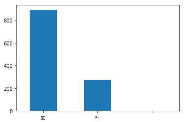

```python
df.gender.value_counts().plot(kind='bar');
```

#### Top Sources

Out of the 4 sources, `Twitter for iPhone` is clearly the most widely used source to share tweets peratining to dogs.

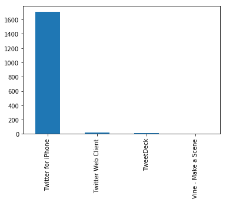

```python
df.source.value_counts().plot(kind='bar');
```

#### Top Names

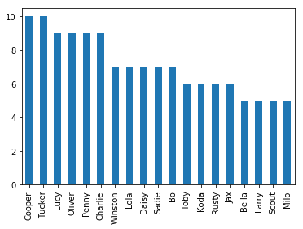

```python
df.name.value_counts()[0:19].plot(kind='bar');
```

#### Top Breeds

`Golden Retriever` is top breed.

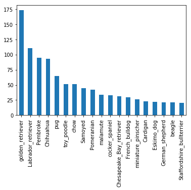

```python
df.breed.value_counts()[0:19].plot(kind='bar');
```

#### Average Retweet and Favorite counts for dog breeds

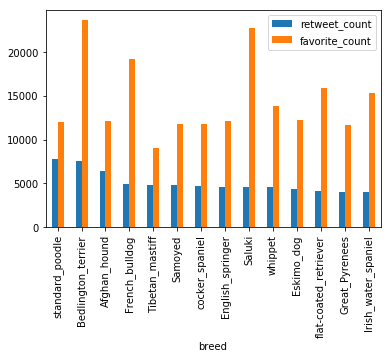

```python
#group by breed and store the means of retweet_count and favorite_count.
df_group = df.groupby(['breed'])['retweet_count', 'favorite_count'].mean()
#order by retweet_count and favorite_count.
df_group = df_group.sort_values(['retweet_count', 'favorite_count'], ascending=False)
#plot the top 15 average counts.
df_group.iloc[0:14,].plot(kind='bar');
```